# Group 8 report

13 5 2020

## The data set

```r
head(prostate_data)
```

```
## # A tibble: 6 x 21
##   patno   age PA_phosphatase bone_metastases diastolic_bp months_of_follo… ekg
##   <dbl> <dbl>          <dbl>           <dbl>        <dbl>            <dbl> <chr>
## 1     1    75          0.300               0            9               72 hear…
## 2     2    54          0.700               0            7                1 hear…
## 3     3    69          0.300               0            8               40 hear…
## 4     4    75          0.900               0            7               20 beni…
## 5     5    67          0.5                 0           10               65 norm…
## 6     6    71          0.600               0           10               24 norm…
## # … with 14 more variables: serum_hemoglobin <dbl>, history_of_CD <dbl>,
## #   activity <chr>, systolic_bp <dbl>, study_date <date>,
## #   stage_grade_index <dbl>, stage <dbl>, tumor_size <dbl>, weight_index <dbl>,
## #   estrogen_mg <dbl>, status_ <chr>, cause_of_death <chr>,
## #   dead_from_prostate_cancer <dbl>, Age_group <chr>
```

## Before analysing the data

- Individual dataframes joined
- Splitting cells containing multiple variables
- Converting strings to numbers
- Grouping numerical varibales in intervals
- Ensuring that all variables are correctly classified

## Identifying and visualising trends with ggplot

## Approach

- A large number of plots were generated quickly to more efficiently identify interesting trends
- For this purpose the same plot was stratified on different factor columns, and in addition pivot_longer() and facet_wrap() was used

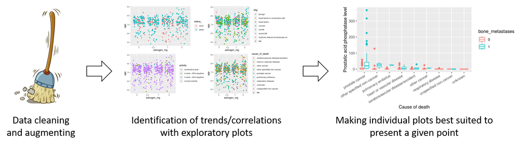

## Tumor size and cause of death

- Prostate cancer showed the second largest tumor size
- Other than prostate cancer, all other causes of death showed difference in stage leads to difference in the tumor size

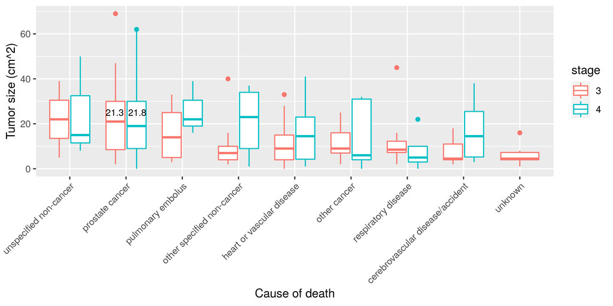

  [Repo](https://github.com/rforbiodatascience/2020_group08/blob/master/R/06_metastases_plots.R) (plot #8)

## Prostatic acid phosphatase and cause of death

- PA phosphatase levels are increased in patients with bone metastases
- PA phosphatase levels are highest in patients that die from prostate cancer

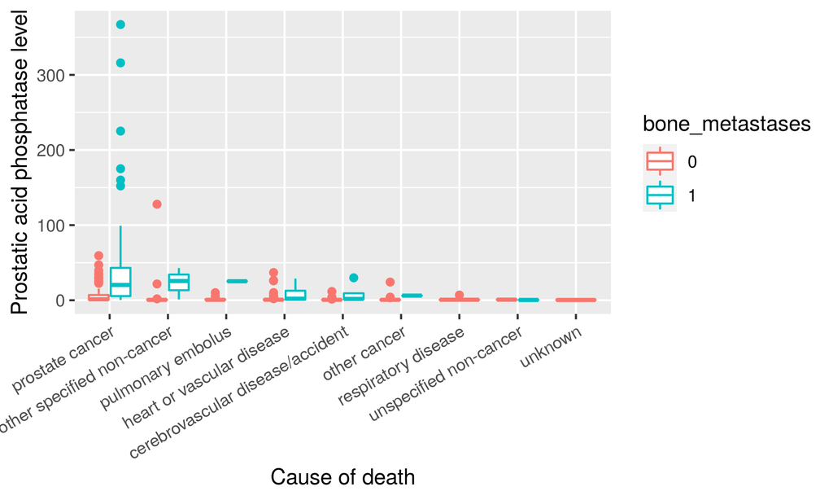

[Repo](https://github.com/rforbiodatascience/2020_group08/blob/master/R/06_metastases_plots.R) (plot #1)

## Tumor size and bone metastases

- Tumors are larger in patients that have died from prostate cancer
- Tumors are larger in patients with metastases

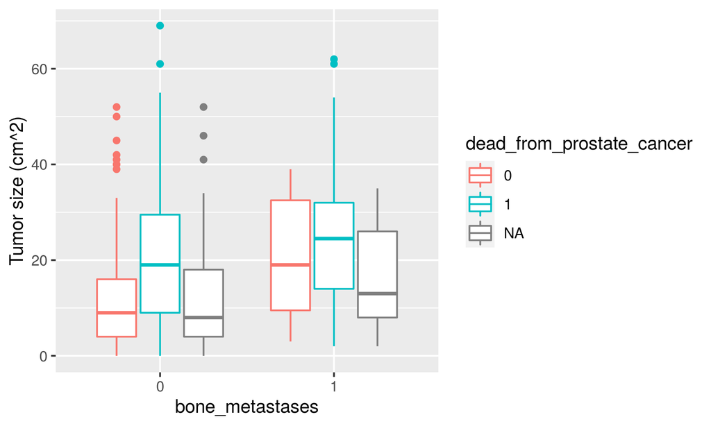

[Repo](https://github.com/rforbiodatascience/2020_group08/blob/master/R/06_metastases_plots.R) (plot #5)

## Status and bone metastases

- Risk of dying from prostate cancer doubles if the cancer spreads from the prostate

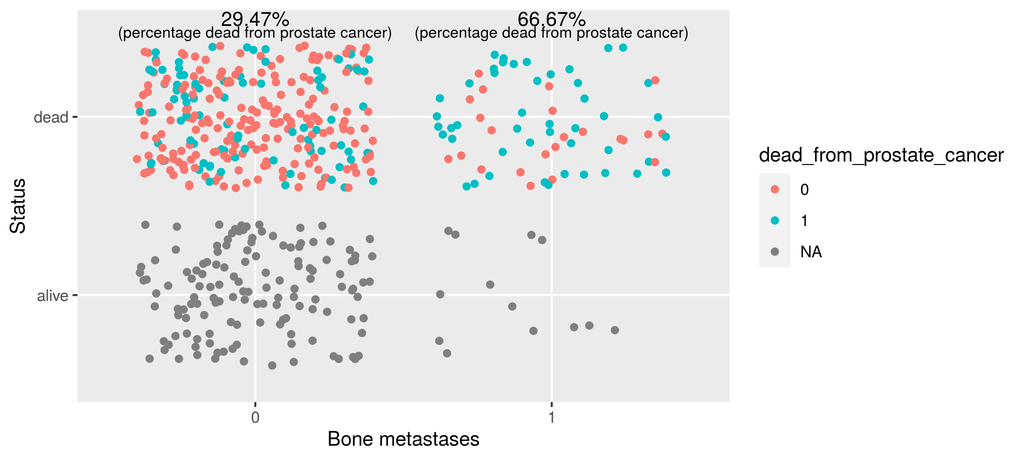

[Repo](https://github.com/rforbiodatascience/2020_group08/blob/master/R/06_metastases_plots.R) (plot #2)

## Serum hemoglobin and bone metastases

- Serum hemoglobin levels are higher in patients without metastases
- Serum hemoglobin levels drop with increased age

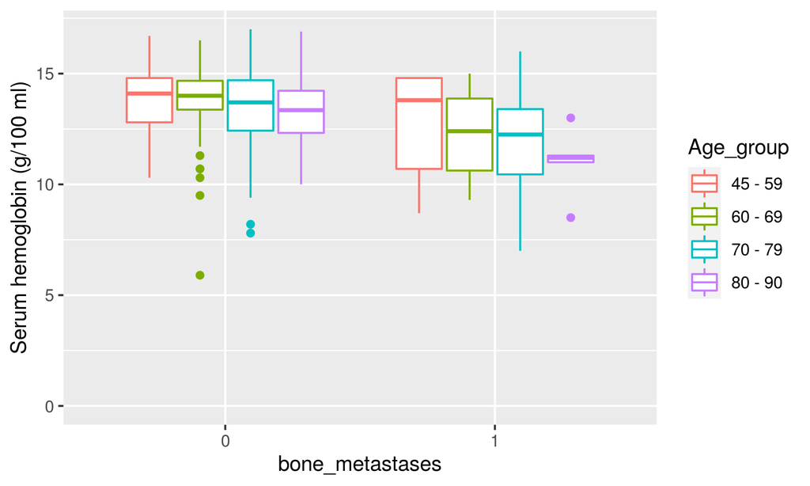

[Repo](https://github.com/rforbiodatascience/2020_group08/blob/master/R/06_metastases_plots.R) (plot #4)

## Activity and bone metastases

- The activity level is affected by disease progress
- Bone metastases leads to reduced activity

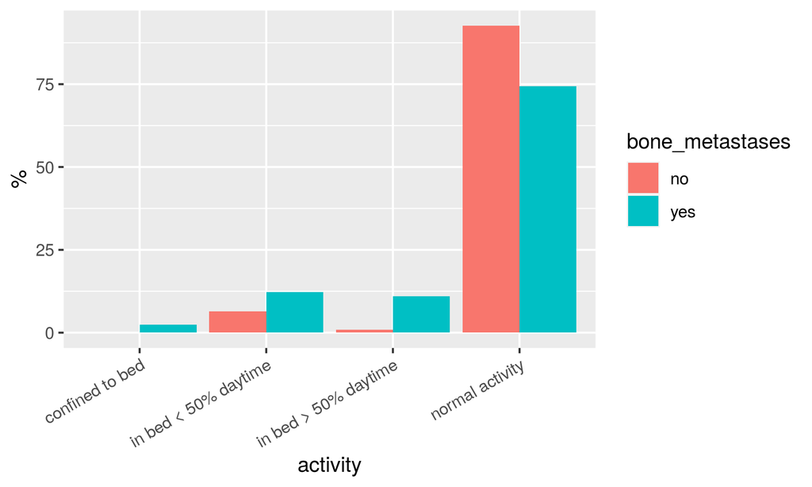

[Repo](https://github.com/rforbiodatascience/2020_group08/blob/master/R/06_metastases_plots.R) (plot #3)

## Estrogen dose and status

- Estrogen is important for survival if the cancer has spread
- High estrogen dose has a negetive effect as age increase

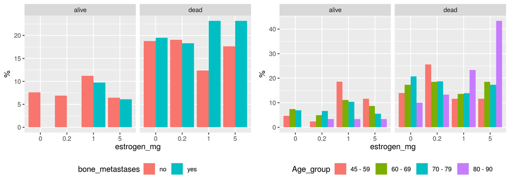

[Repo](https://github.com/rforbiodatascience/2020_group08/blob/master/R/06_metastases_plots.R) (plot #6 and #7)

## Predictive models and ANN

## Linear regression of blood pressure

- The only linear regression model that fit well was for diastolic blood pressure vs systolic blood pressure, grouped by cause of death
- The best fit is for patients that have died from respiratory disease

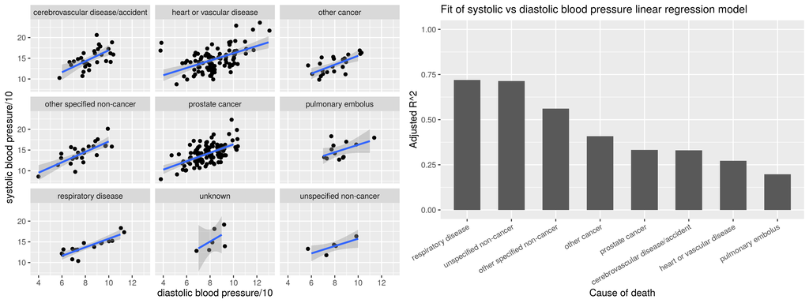

Repo

## Predicting death cause with logistic regression

- The most important predictors for predicting if a patient died from prostate cancer (determined from ANOVA) were stage/grade index and prostatic acid phosphatase levels
- 5-fold cross validation gave a model accuracy of 74.5%

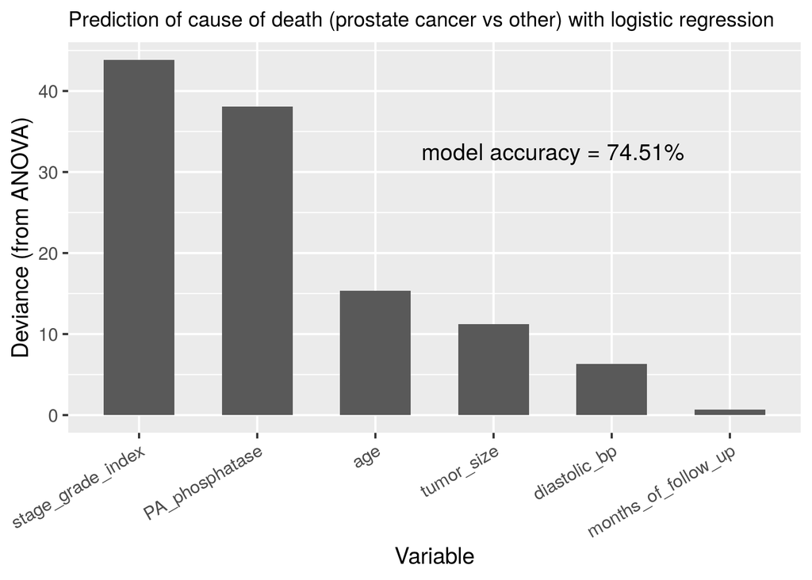

[Repo](https://github.com/rforbiodatascience/2020_group08/blob/master/R/04_glm_death_prediction.R)

## Predicting cause of death with ANN

- The ANN predicts on 10 different outcomes
- The ANN was trained through 200 epochs, accuracy is shown in the plot

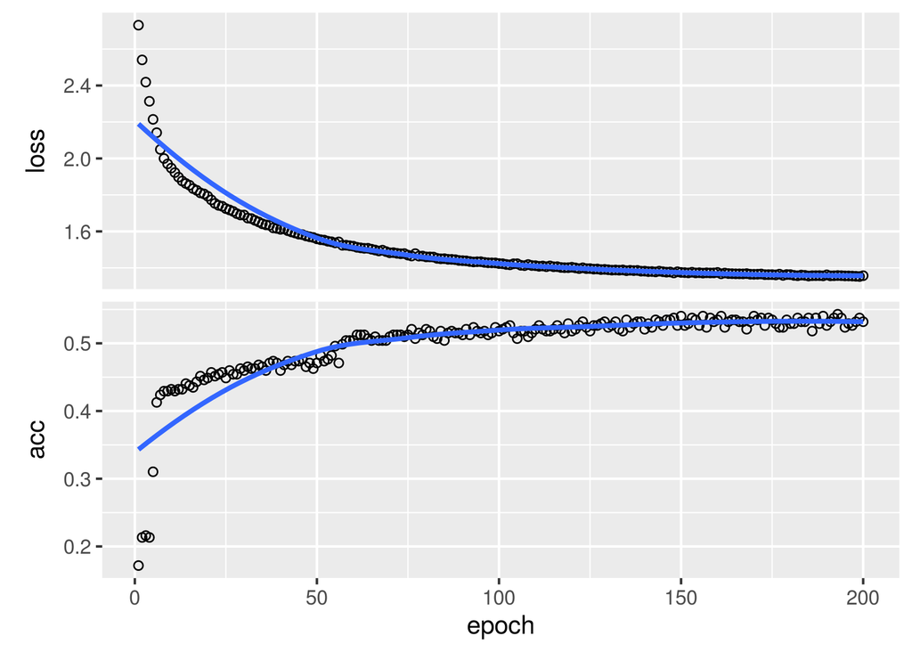

[Repo](https://github.com/rforbiodatascience/2020_group08/blob/master/R/08_keras_ANN.R)

## Clustering

## Identifying clusters with PCA

- A PCA analysis is used to look for groupings and patterns of the data based on all variables
- PCA analysis is not well suited for this data, since a single PCA cannot explain a lot of the variance levels
- PC #1 only explains 22.5% of the variance

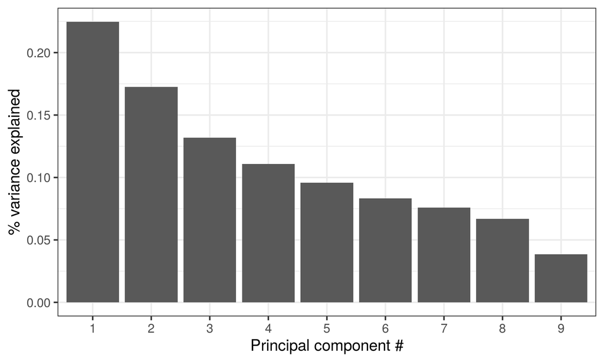

[Repo](https://github.com/rforbiodatascience/2020_group08/blob/master/R/07_PCA.R)

## Identifying clusters with PCA

- No clear clusters could be identified
- The best clusters are found when stratifying by status and if a person developed bone metastases

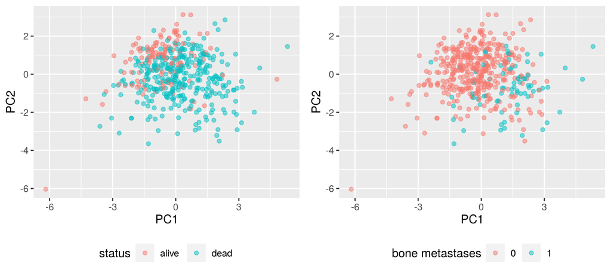

[Repo](https://github.com/rforbiodatascience/2020_group08/blob/master/R/07_PCA.R)

## Conclusions

- Prostatic acid (PA) phosphatase levels are higher in patients with metastases and that have died from prostate cancer
- The risk of dying from prostate cancer increases with larger tumors
- Serum hemoglobin levels are lower in older patients with bone metastases
- When the cancer has metastasized the patients are less active and there is a much bigger risk of dying
- High doses of estrogen have negative effects for older patients
- Logistic regression can predict with 75% accuracy if a patient have died from prostate cancer, with the most important predictors being stage/grade index and PA phosphatase levels
- An ANN was created with the aim of predicting the cause of death
- The data has no clearly seperated clusters